# Population Genetics Analysis of Arabidopsis thaliana

# 8. Display Results

```r
cat("\nDisplaying plots...\n\n")
```

```
##
## Displaying plots...
```

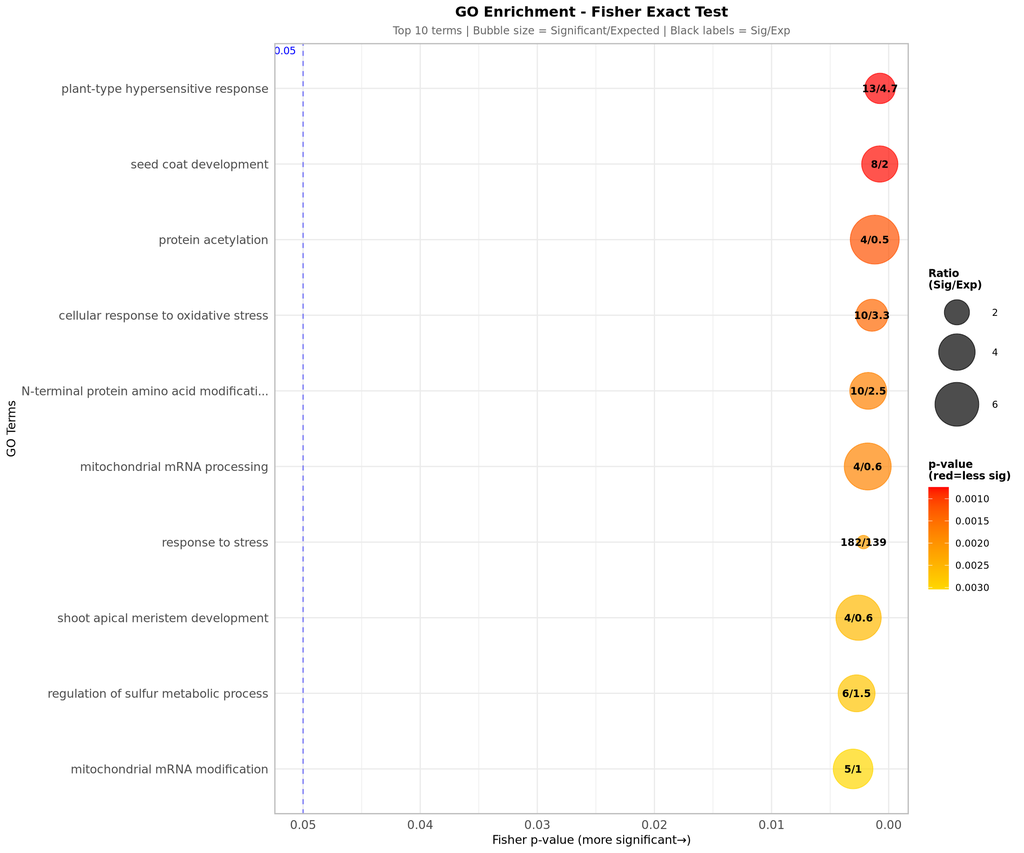

```r
print(p_fisher)
```

```r
cat("\n--- FISHER EXACT TEST ---\n")
```

```
##
## --- FISHER EXACT TEST ---
```

```r
cat("• Shows if GO terms have more significant genes than expected\n")
```

```
## • Shows if GO terms have more significant genes than expected
```

```r
cat("• Bubble size = Significant/Expected (biological signal strength)\n")
```

```
## • Bubble size = Significant/Expected (biological signal strength)
```

```r
cat("• Black labels show actual counts: ", ggdata_Fisher$Sig_Expected_label[1], " etc.\n\n")
```

```
## • Black labels show actual counts:  13/4.7  etc.
```

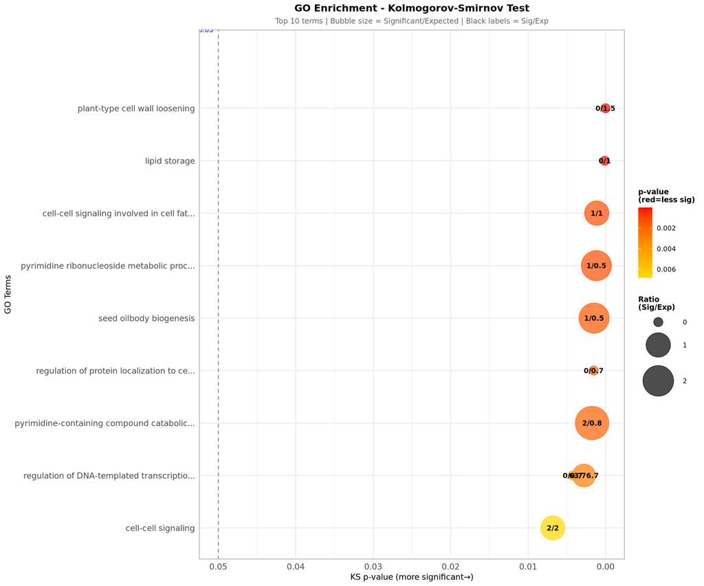

```r
print(p_ks)
```

```r
cat("\n--- KOLMOGOROV-SMIRNOV TEST ---\n")
```

```
##
## --- KOLMOGOROV-SMIRNOV TEST ---
```

```r
cat("• Tests if genes in GO term have systematically higher FST values\n")
```

```
## • Tests if genes in GO term have systematically higher FST values
```

```r
cat("• Different statistical approach than Fisher test\n")
```

```
## • Different statistical approach than Fisher test
```

```r
cat("• Can detect subtle shifts in distribution\n\n")
```

```
## • Can detect subtle shifts in distribution
```

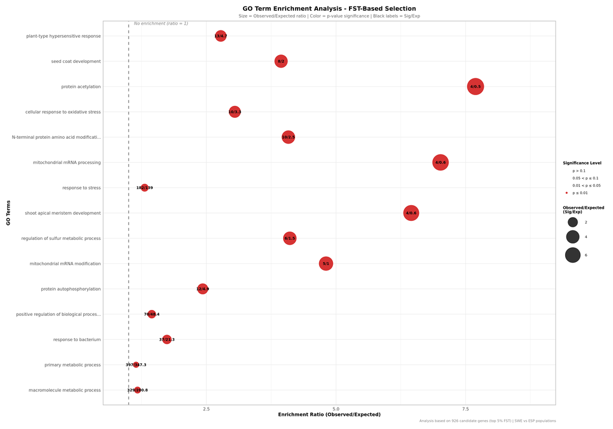

```r
print(p_combined)
```

```r
cat("\n--- COMBINED ENRICHMENT VIEW ---\n")
```

```
##
## --- COMBINED ENRICHMENT VIEW ---
```

```r
cat("• Shows relationship between enrichment magnitude and significance\n")
```

```
## • Shows relationship between enrichment magnitude and significance
```

# 9. Analysis Summary

```r
cat("\n=== ANALYSIS SUMMARY ===\n\n")
```

```
##
## === ANALYSIS SUMMARY ===
```

```r
summary_stats <- data.frame(
  Metric = c(
    "Total SNPs analyzed",
    "Mean FST value",
    "FST threshold (95th percentile)",
    "SNPs above FST threshold",
    "Genes with SNP coverage",
    "Candidate genes (top 5% FST)",
    "Top candidate gene FST",
    "GO terms analyzed",
    "GO terms with FDR < 0.05",
    "Most enriched GO term",
    "Highest enrichment ratio"
  ),
  Value = c(
    format(nrow(fst_data), big.mark = ","),
    round(mean(fst_data$FST, na.rm = TRUE), 4),
    round(fst_threshold, 4),
    format(sum(fst_data$FST >= fst_threshold, na.rm = TRUE), big.mark = ","),
    format(length(unique(snp_gene_map$gene_id)), big.mark = ","),
    format(nrow(candidate_genes), big.mark = ","),
    ifelse(nrow(candidate_genes) > 0,
           paste(candidate_genes$gene_id[1], " (FST = ", round(candidate_genes$max_FST[1], 4), ")", sep = ""),
           "None"),
    nrow(go_enrichment),
    sum(go_enrichment$FDR_adjusted < 0.05),
    ifelse(nrow(go_enrichment) > 0, go_enrichment$Term[1], "None"),
    ifelse(nrow(go_enrichment) > 0, round(max(go_enrichment$Enrichment_ratio, na.rm = TRUE), 2), "NA")
  )
)

# Print as a nice table
knitr::kable(
  summary_stats,
  col.names = c("Metric", "Value"),
  align = c("l", "r"),
  caption = "Summary of FST and GO Enrichment Analysis"
)
```

Summary of FST and GO Enrichment Analysis

[output not shown]

```r
cat("\n=== BIOLOGICAL INTERPRETATION ===\n\n")
```

```
##
## === BIOLOGICAL INTERPRETATION ===
```

```r
if(nrow(go_enrichment) > 0 && any(go_enrichment$FDR_adjusted < 0.05)) {
  sig_terms <- go_enrichment[go_enrichment$FDR_adjusted < 0.05, ]
  cat("Significant enrichment found in", nrow(sig_terms), "GO terms:\n")
  for(i in 1:min(3, nrow(sig_terms))) {
    cat(paste0("  ", i, ". ", sig_terms$Term[i],
               " (Enrichment = ", round(sig_terms$Enrichment_ratio[i], 2),
               ", FDR = ", format(sig_terms$FDR_adjusted[i], scientific = TRUE, digits = 2), ")\n"))
  }
  cat("\nThese processes are likely under divergent selection between\n")
  cat("Swedish and Spanish Arabidopsis populations, potentially related\n")
  cat("to climate adaptation differences.\n")
} else {
  cat("No GO terms reach FDR significance (FDR < 0.05). This suggests:\n")
  cat("1. Polygenic adaptation (many genes with small effects)\n")
  cat("2. Selection on uncharacterized pathways\n")
  cat("3. Technical limitations (sample size, filtering thresholds)\n")
  cat("4. Demographic history mimicking selection signals\n\n")

  if(nrow(go_enrichment) > 0) {
    cat("Top nominal enrichment (lowest p-values):\n")
    for(i in 1:min(3, nrow(go_enrichment))) {
      cat(paste0("  ", i, ". ", go_enrichment$Term[i],
                 " (p = ", format(go_enrichment$Fisher_p_value[i], scientific = TRUE, digits = 2),
                 ", Enrichment = ", round(go_enrichment$Enrichment_ratio[i], 2), ")\n"))
    }
  }
}
```

[output not shown]

```r
cat("\n=== STATISTICAL CAVEATS ===\n")
```

```
##
## === STATISTICAL CAVEATS ===
```

```r
cat("• FST outliers can arise from demographic history (e.g., bottlenecks)\n")
```

```
## • FST outliers can arise from demographic history (e.g., bottlenecks)
```

```r
cat("• Multiple testing correction reduces power for weak signals\n")
```

```
## • Multiple testing correction reduces power for weak signals
```

```r
cat("• Gene-based aggregation assumes functional equivalence of SNPs\n")
```

```
## • Gene-based aggregation assumes functional equivalence of SNPs
```

```r
cat("• GO analysis depends on annotation completeness\n")
```

```
## • GO analysis depends on annotation completeness
```

```r
cat("\n=== RECOMMENDED NEXT STEPS ===\n")
```

```
##
## === RECOMMENDED NEXT STEPS ===
```

```r
cat("1. Validate candidate genes with independent population data\n")
```

```
## 1. Validate candidate genes with independent population data
```

```r
cat("2. Examine gene family expansions/contractions\n")
```

```
## 2. Examine gene family expansions/contractions
```

```r
cat("3. Correlate with climate variables (temperature, precipitation)\n")
```

```
## 3. Correlate with climate variables (temperature, precipitation)
```

```r
cat("4. Functional validation of top candidate genes\n")
```

```
## 4. Functional validation of top candidate genes
```

# 10. Should You Use Defense-Only Or Full Genome Data?

## 10.1. Defense-Only Analysis: Why This Is Correct

### Scientific justification

If your **a priori biological hypothesis** concerns defense-related genes (e.g., immune response, pathogen interaction, hypersensitive response), then restricting the GO enrichment universe to defense-annotated genes is **hypothesis-driven**, not post hoc.

This is critical: You are not “cherry-picking”; you are testing a **predefined functional class** motivated by biology.

### Statistical advantages

Using defense genes only:

- Reduces the multiple-testing burden
- Increases statistical power
- Improves interpretability of enriched terms
- Avoids dilution of signal by unrelated housekeeping functions

This is especially appropriate when:

- Selection is expected to act on a specific biological system
- Effect sizes are moderate (polygenic adaptation)
- Genome-wide enrichment is weak or absent

### Appropriate use cases

✔ Main GO enrichment analysis  
✔ Hypothesis testing (“Are defense pathways overrepresented among high-FST genes?”)  
✔ Core biological conclusions

## 10.2. Genome-Wide Analysis: Why You Still Need It

Using the full genome is **not redundant**—it serves a different purpose.

### Genome-wide data provide:

- A null expectation for FST distributions
- Context for interpreting effect sizes
- Validation that defense genes are not trivially extreme due to annotation bias
- Protection against accusations of circular reasoning

### Appropriate use cases

✔ Supplemental figures  
✔ Validation analyses  
✔ Descriptive context  
✔ Discussion and interpretation

This distinction is methodologically clean and reviewers generally welcome it.

## 10.3. Recommended Structure (Best Practice)

Your proposed structure is exactly right:

### Main manuscript

- GO enrichment restricted to defense genes
- Focused hypothesis testing
- Clear biological narrative
- Stronger statistical power

### Supplementary material

- Genome-wide FST distributions
- Comparison of defense vs non-defense genes
- Permutation or empirical quantile validation (optional but strong)

### Discussion

- Explicit comparison of defense genes to genome-wide expectations
- Interpretation of why genome-wide enrichment may be weak
- Framing in terms of polygenic or pathway-specific adaptation

This approach balances **rigor, power, and transparency**.

## 10.4. One Critical Caveat (Must Be Explicit in Methods)

You **must clearly define the background (gene universe)** in each analysis.

Specifically:

- Defense-only GO analysis
  - Background = all defense-annotated genes
- Genome-wide analysis
  - Background = all genes with FST estimates

Failing to state this explicitly is the most common reviewer criticism.

## 10.5. Summary

> *To test the hypothesis that local adaptation is enriched in defense-related pathways, we performed Gene Ontology enrichment analyses restricted to genes annotated with defense-associated GO terms. This hypothesis-driven approach reduces multiple testing and increases power to detect pathway-level selection acting on immune and stress-response processes. To provide genome-wide context, we additionally analyzed the distribution of FST values across all genes and compared defense genes to the genomic background. Genome-wide analyses are presented as supplementary material and serve to validate that defense-associated genes represent outliers relative to genome-wide expectations.*

**Remember:** This current analysis uses the full genome. For a defense-focused study, you would need to:

1. Pre-filter your FST data to defense genes only
2. Adjust the background universe in the GO enrichment step
3. Still include a genome-wide comparison in supplements for context